# TugasPrak7

# Packages

```r
library(ggplot2)
library(tsibble)
library(tseries)
library(MASS)
library(forecast)
library(TSA)
library(TTR)
library(aTSA)
library(graphics)
```

# Data

Data yang digunakan adalah data harga rata-rata saham IHSG sebanyak 100 periode yang diambil dari Yahoo Finance

```r
data <- readxl::read_excel("/Users/fauzanfajari/Documents/Kuliah/V/MPDW/IHSG.xlsx", sheet = "Sheet1")
head(data)
```

```
## # A tibble: 6 × 2
##   Periode Harga
##     <dbl> <dbl>
## 1       1 7331.
## 2       2 7338.
## 3       3 7350.
## 4       4 7378.
## 5       5 7366.
## 6       6 7310.
```

# Eksplorasi Data

## Plot Data Penuh

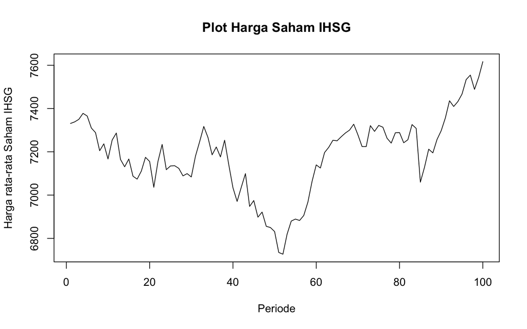

```r
dt <- ts(data$Harga)
plot.ts(dt, lty=1, xlab="Periode", ylab="Harga rata-rata Saham IHSG", main="Plot Harga Saham IHSG")
```

Berdasarkan plot diatas, terlihat bahwa data tidak memiliki pola stasioner karena memiliki tren trun pada periode tertentu dan naik pada periode tertentu.

## Plot Data Latih

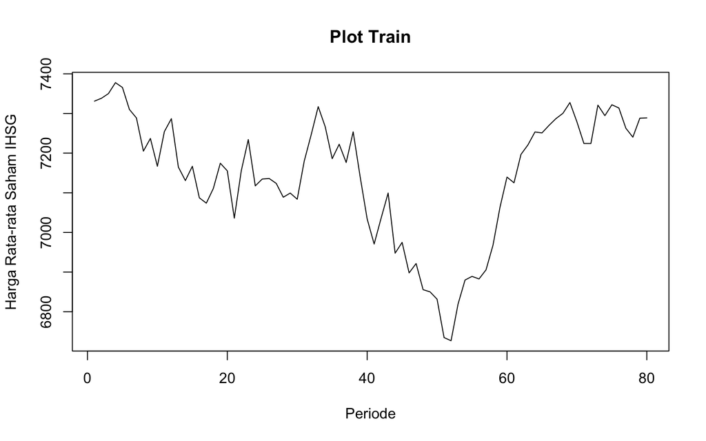

```r
train.ts <- ts(dt[1:80])
plot.ts(train.ts, lty=1, xlab="Periode", ylab="Harga Rata-rata Saham IHSG", main="Plot Train")
```

## Plot Data Uji

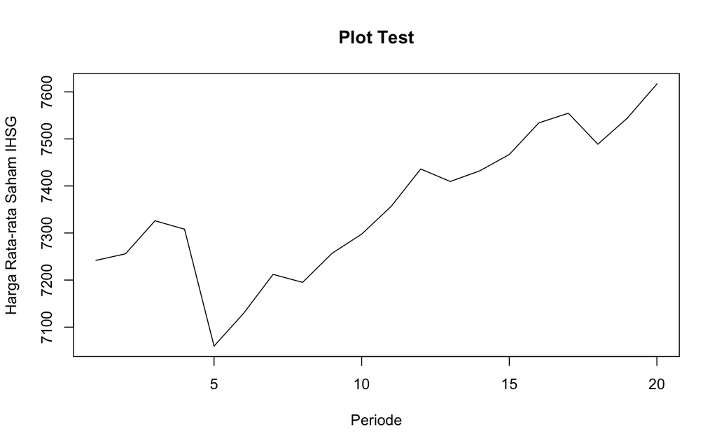

```r
test.ts <- ts(dt[81:100])
plot.ts(test.ts, lty=1, xlab="Periode", ylab="Harga Rata-rata Saham IHSG", main="Plot Test")
```

# Uji Stasioneritas Data

Selanjutnya, akan dilakukan eksplorasi dan uji formal untuk melihat apakah data stasioner atau tidak

## Plot ACF

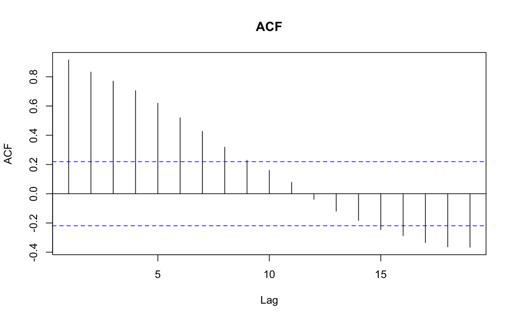

```r
acf(train.ts, main="ACF")
```

Berdasarkan plot acf diatas, terlihat bahwa plot acf memiliki pola “tails off slowly” atau ekor yang menurun perlahan. Hal ini menunjukkan bahwa data tidak stasioner.

## Uji ADF

```r
tseries::adf.test(train.ts)
```

```
##
##  Augmented Dickey-Fuller Test
##
## data:  train.ts
## Dickey-Fuller = -1.7752, Lag order = 4, p-value = 0.6677
## alternative hypothesis: stationary
```

Berdasarkan uji ADF tersebut, didapat *p-value* sebesar 0.6677 yang lebih besar dari taraf nyata 5% sehingga tidak tolak $H_0$ dan menandakan bahwa data tidak stasioner dalam rataan.

## Plot Box-Cox

```r
index <- seq(1:80)
bc = boxcox(train.ts~index, lambda = seq(0,20,by=1))
```

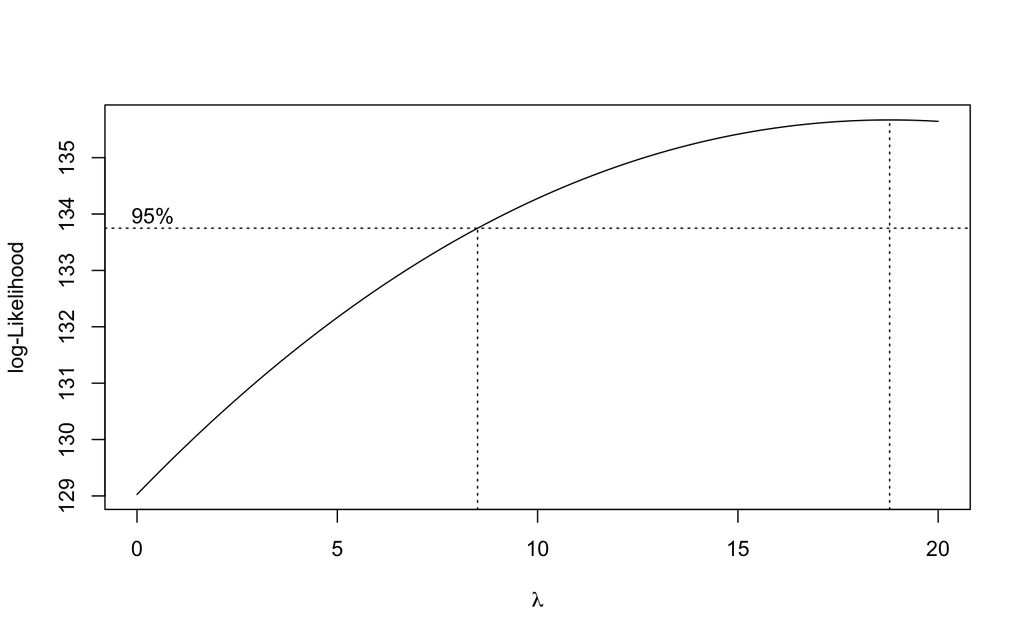

```r
#Nilai Rounded Lambda
lambda <- bc$x[which.max(bc$y)]
lambda
```

```
## [1] 18.78788
```

```r
#SK
bc$x[bc$y > max(bc$y) - 1/2 * qchisq(.95,1)]
```

```
##  [1]  8.686869  8.888889  9.090909  9.292929  9.494949  9.696970  9.898990
##  [8] 10.101010 10.303030 10.505051 10.707071 10.909091 11.111111 11.313131
## [15] 11.515152 11.717172 11.919192 12.121212 12.323232 12.525253 12.727273
## [22] 12.929293 13.131313 13.333333 13.535354 13.737374 13.939394 14.141414
## [29] 14.343434 14.545455 14.747475 14.949495 15.151515 15.353535 15.555556
## [36] 15.757576 15.959596 16.161616 16.363636 16.565657 16.767677 16.969697
## [43] 17.171717 17.373737 17.575758 17.777778 17.979798 18.181818 18.383838
## [50] 18.585859 18.787879 18.989899 19.191919 19.393939 19.595960 19.797980
## [57] 20.000000
```

Berdasarkan data diatas, didapatkan bahwa plot tersebut tidak stasioner dalam ragam

# Penanganan Ketidak-Stasioneran

## Differencing

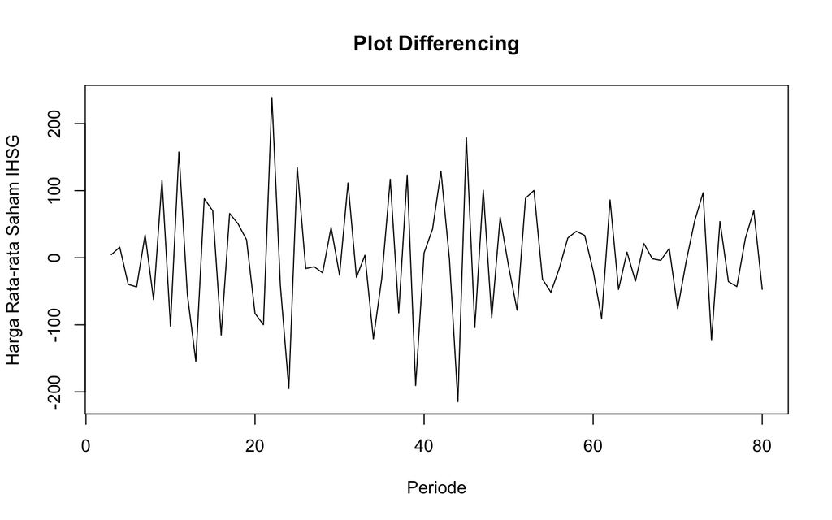

```r
train.diff<-diff(train.ts,differences = 2)
plot.ts(train.diff, lty=1, xlab="Periode", ylab="Harga Rata-rata Saham IHSG", main="Plot Differencing")
```

## ACF Differencing

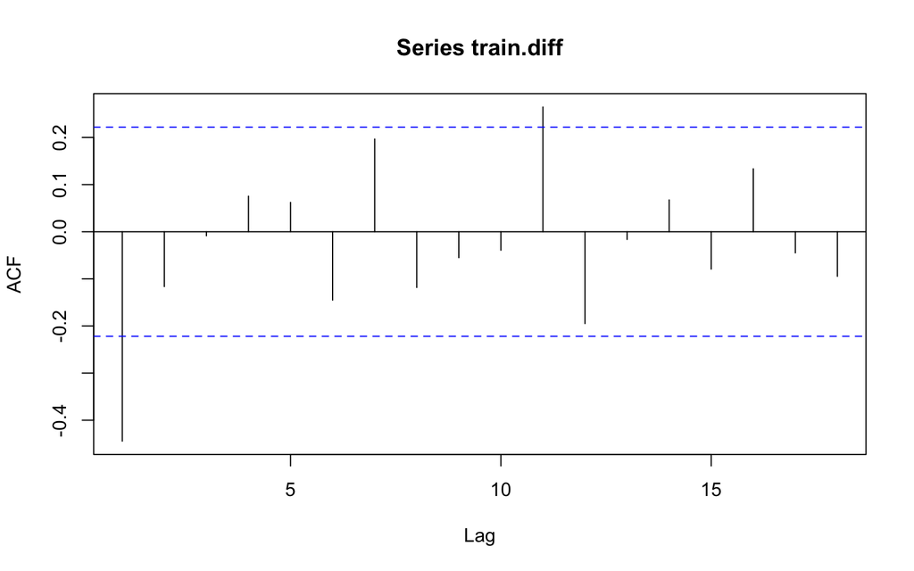

```r
acf(train.diff)
```

Berdasarkan plot tersebut, terlihat bahwa plot ACF cuts off pada lag ke 1, sehingga data sudah stasioner dalam rataan

## Uji ADF Differencing

```r
tseries::adf.test(train.diff)
```

```
##
##  Augmented Dickey-Fuller Test
##
## data:  train.diff
## Dickey-Fuller = -6.7946, Lag order = 4, p-value = 0.01
## alternative hypothesis: stationary
```

Berdasarkan uji ADF tersebut, didapat *p-value* sebesar 0.01 yang lebih kecil dari taraf nyata 5% sehingga tolak $H_0$ atau data masih stasioner dalam rataan. Hal ini sesuai dengan hasil eksplorasi menggunakan plot time series dan plot ACF. Selanjutnya, kita akan melakukan identifikasi model

# Identifikasi Model

## Plot ACF

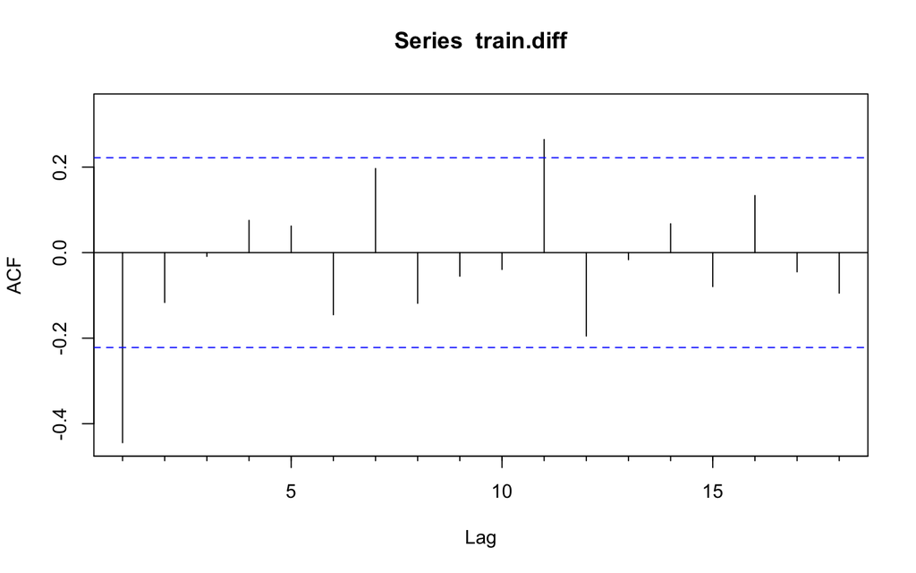

```r
Acf(train.diff)
```

Berdasarkan plot tersebut, terlihat bahwa plot ACF cenderung *cuts off* pada lag ke 1, sehingga jika plot PACF dianggap *tails off*, maka model tentatifnya adalah ARIMA(0,2,1).

## Plot PACF

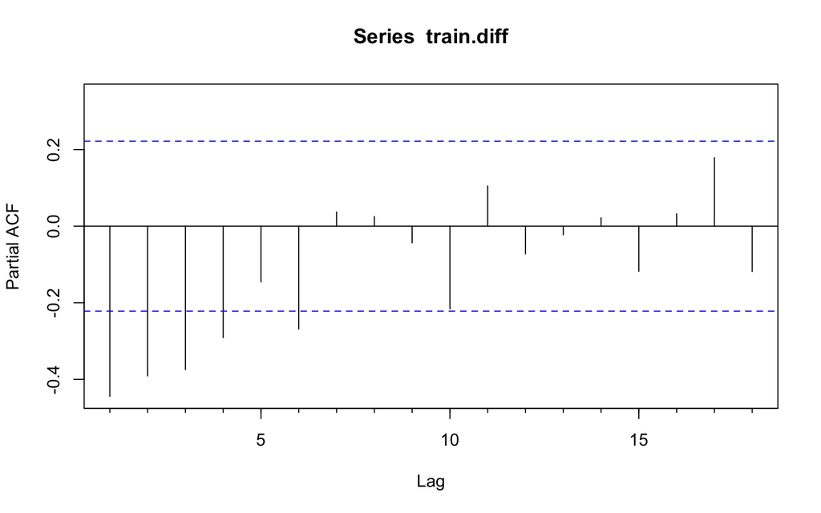

```r
Pacf(train.diff)
```

## Plot EACF

```r
eacf(train.diff)
```

```
## AR/MA
##   0 1 2 3 4 5 6 7 8 9 10 11 12 13
## 0 x o o o o o o o o o x  o  o  o
## 1 x o o o o o o o o o x  o  o  o
## 2 x o o o o o o o o o x  o  o  o
## 3 x o o o o o o o o o o  o  o  o
## 4 x x o o o o o o o o o  o  o  o
## 5 x x o x o x o o o o o  o  o  o
## 6 o o o x o x o o o o o  o  o  o
## 7 x o o x o x o o o o o  o  o  o
```

Berdasarkan plot EACF, model tentatif yang terbentuk adalah ARIMA(0,2,1), ARIMA(0,2,2), ARIMA(1,2,1) dan ARIMA(1,2,2).

# Pendugaa Parameter Model Tentatif

## ARIMA(0,2,1)

```r
model1.da=Arima(train.diff, order=c(0,2,1),method="ML")
summary(model1.da)
```

```
## Series: train.diff
## ARIMA(0,2,1)
##
## Coefficients:
##           ma1
##       -1.0000
## s.e.   0.0323
##
## sigma^2 = 22416:  log likelihood = -490.17
## AIC=984.35   AICc=984.51   BIC=989.01
##
## Training set error measures:
##                     ME    RMSE      MAE      MPE     MAPE      MASE       ACF1
## Training set -0.312712 146.812 113.5647 277.7516 329.1245 0.9855514 -0.6100123
```

```r
lmtest::coeftest(model1.da)
```

```
##
## z test of coefficients:
##
##      Estimate Std. Error z value  Pr(>|z|)
## ma1 -0.999999   0.032301 -30.959 < 2.2e-16 ***
## ---
## Signif. codes:  0 '***' 0.001 '**' 0.01 '*' 0.05 '.' 0.1 ' ' 1
```

## ARIMA(0,2,2)

```r
model2.da=Arima(train.diff, order=c(0,2,2),method="ML")
summary(model2.da)
```

```
## Series: train.diff
## ARIMA(0,2,2)
##
## Coefficients:
##           ma1     ma2
##       -1.9891  0.9999
## s.e.   0.0483  0.0468
##
## sigma^2 = 7965:  log likelihood = -454.09
## AIC=914.18   AICc=914.52   BIC=921.17
##
## Training set error measures:
##                      ME     RMSE      MAE      MPE    MAPE     MASE       ACF1
## Training set -0.7663865 86.93085 68.16476 101.4947 104.774 0.591556 -0.4346252
```

```r
lmtest::coeftest(model2.da)
```

```
##
## z test of coefficients:
##
##      Estimate Std. Error z value  Pr(>|z|)
## ma1 -1.989056   0.048269 -41.207 < 2.2e-16 ***
## ma2  0.999886   0.046841  21.346 < 2.2e-16 ***
## ---
## Signif. codes:  0 '***' 0.001 '**' 0.01 '*' 0.05 '.' 0.1 ' ' 1
```

## ARIMA(1,2,1)

```r
model3.da=Arima(train.diff, order=c(1,2,1),method="ML")
summary(model3.da)
```

```
## Series: train.diff
## ARIMA(1,2,1)
##
## Coefficients:
##           ar1      ma1
##       -0.6032  -1.0000
## s.e.   0.0899   0.0327
##
## sigma^2 = 14168:  log likelihood = -472.92
## AIC=951.85   AICc=952.18   BIC=958.84
##
## Training set error measures:
##                    ME     RMSE      MAE      MPE     MAPE      MASE       ACF1
## Training set 1.097633 115.9372 88.79998 122.0345 212.9645 0.7706353 -0.3002834
```

```r
lmtest::coeftest(model3.da)
```

```
##
## z test of coefficients:
##
##      Estimate Std. Error  z value  Pr(>|z|)
## ar1 -0.603226   0.089936  -6.7073 1.983e-11 ***
## ma1 -1.000000   0.032738 -30.5453 < 2.2e-16 ***
## ---
## Signif. codes:  0 '***' 0.001 '**' 0.01 '*' 0.05 '.' 0.1 ' ' 1
```

## ARIMA(1,2,2)

```r
model4.da=Arima(train.diff, order=c(1,2,2),method="ML")
summary(model4.da)
```

```
## Series: train.diff
## ARIMA(1,2,2)
##
## Coefficients:
##           ar1      ma1     ma2
##       -0.4221  -1.9919  1.0000
## s.e.   0.1030   0.0493  0.0485
##
## sigma^2 = 6483:  log likelihood = -446.7
## AIC=901.39   AICc=901.95   BIC=910.71
##
## Training set error measures:
##                      ME     RMSE      MAE      MPE     MAPE      MASE
## Training set -0.9467972 77.89384 58.96787 25.05747 141.4235 0.5117424
##                    ACF1
## Training set -0.1755684
```

```r
lmtest::coeftest(model4.da)
```

```
##
## z test of coefficients:
##
##     Estimate Std. Error  z value  Pr(>|z|)
## ar1 -0.42207    0.10300  -4.0979 4.169e-05 ***
## ma1 -1.99190    0.04926 -40.4361 < 2.2e-16 ***
## ma2  0.99996    0.04846  20.6348 < 2.2e-16 ***
## ---
## Signif. codes:  0 '***' 0.001 '**' 0.01 '*' 0.05 '.' 0.1 ' ' 1
```

## Kesimpulan

Dari Identifikasi diatas, model dengan nilai AIC terkecil dan signifikan pada semua parameter adalah ARIMA(1,2,2). Selanjutnya, kita akan melakukan diagnostik model tersebut

# Analisis Sisaan

## Plot Residual

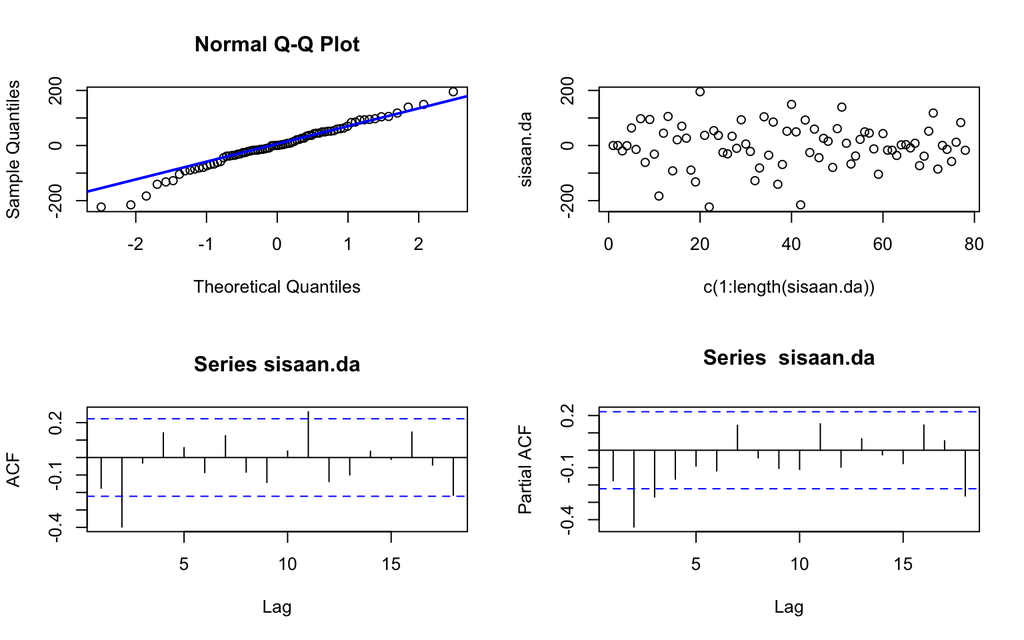

```r
sisaan.da <- model4.da$residuals
par(mfrow=c(2,2))
qqnorm(sisaan.da)
qqline(sisaan.da, col = "blue", lwd = 2)
plot(c(1:length(sisaan.da)),sisaan.da)
acf(sisaan.da)
pacf(sisaan.da)
```

## Uji Formal

### Normalitas Sisaan

```r
ks.test(sisaan.da,"pnorm")
```

```
##
##  Exact one-sample Kolmogorov-Smirnov test
##
## data:  sisaan.da
## D = 0.48035, p-value = 3.331e-16
## alternative hypothesis: two-sided
```

Berdasarkan uji Kolmogorov-Smirnov, didapatkan *p-value* < alpha, sehingga disimpulkan tolak $H_0$ dan menandakan bahwa sisaan tidak berdistribusi normal.

### Sisaan Saling Bebas

```r
Box.test(sisaan.da, type = "Ljung")
```

```
##
##  Box-Ljung test
##
## data:  sisaan.da
## X-squared = 2.498, df = 1, p-value = 0.114
```

Berdasarkan uji Box-Ljung, didapatkan *p-value* > alpha, sehingga disimpulkan tidak tolak $H_0$ dan menandakan bahwa sisaan saling bebas.

### Ragam Sisaan Homogen

```r
Box.test((sisaan.da)^2, type = "Ljung")
```

```
##
##  Box-Ljung test
##
## data:  (sisaan.da)^2
## X-squared = 0.021469, df = 1, p-value = 0.8835
```

Berdasarkan uji Box-Ljung, didapatkan *p-value* > alpha, sehingga disimpulkan tidak tolak $H_0$ dan menandakan bahwa ragam sisaan homogen

### Nilai Tengah Sisaan Nol

```r
t.test(sisaan.da, mu = 0, conf.level = 0.95)
```

```
##
##  One Sample t-test
##
## data:  sisaan.da
## t = -0.10667, df = 77, p-value = 0.9153
## alternative hypothesis: true mean is not equal to 0
## 95 percent confidence interval:
##  -18.62151  16.72792
## sample estimates:
##  mean of x
## -0.9467972
```

Berdasarkan uji t, didapatkan *p-value* > alpha, sehingga disimpulkan tidak tolak $H_0$ dan menandakan bahwa nilai tengah sisaan nol.

# Forecasting

```r
ramalan.da <- forecast::forecast(model4.da, h = 20)
ramalan.da
```

```
##     Point Forecast      Lo 80    Hi 80     Lo 95    Hi 95
##  81     19.3308829  -85.10287 123.7646 -140.3868 179.0485
##  82     -8.8865157 -120.97590 103.2029 -180.3124 162.5394
##  83      2.8695545 -111.23653 116.9756 -171.6406 177.3798
##  84     -2.2459260 -116.41744 111.9256 -176.8562 172.3643
##  85     -0.2404528 -114.65896 114.1781 -175.2285 174.7476
##  86     -1.2405113 -115.71091 113.2299 -176.3079 173.8269
##  87     -0.9720289 -115.60175 113.6577 -176.2831 174.3390
##  88     -1.2389580 -116.01636 113.5384 -176.7759 174.2979
##  89     -1.2799066 -116.25702 113.6972 -177.1222 174.5624
##  90     -1.4162346 -116.62028 113.7878 -177.6056 174.7732
##  91     -1.5123059 -116.98607 113.9615 -178.1142 175.0896
##  92     -1.6253682 -117.40848 114.1577 -178.7004 175.4496
##  93     -1.7312592 -117.86862 114.4061 -179.3480 175.8855
##  94     -1.8401770 -118.37801 114.6977 -180.0694 176.3891
##  95     -1.9478172 -118.93533 115.0397 -180.8648 176.9691
##  96     -2.0559967 -119.54451 115.4325 -181.7392 177.6272
##  97     -2.1639486 -120.20712 115.8792 -182.6954 178.3675
##  98     -2.2719965 -120.92556 116.3816 -183.7370 179.1930
##  99     -2.3800039 -121.70174 116.9417 -184.8668 180.1068
## 100     -2.4880284 -122.53757 117.5615 -186.0880 181.1119
```

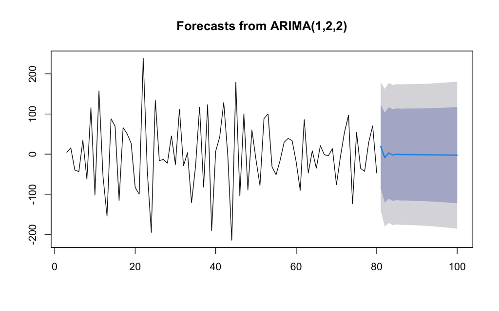

```r
data.ramalan.da <- ramalan.da$mean
plot(ramalan.da)
```

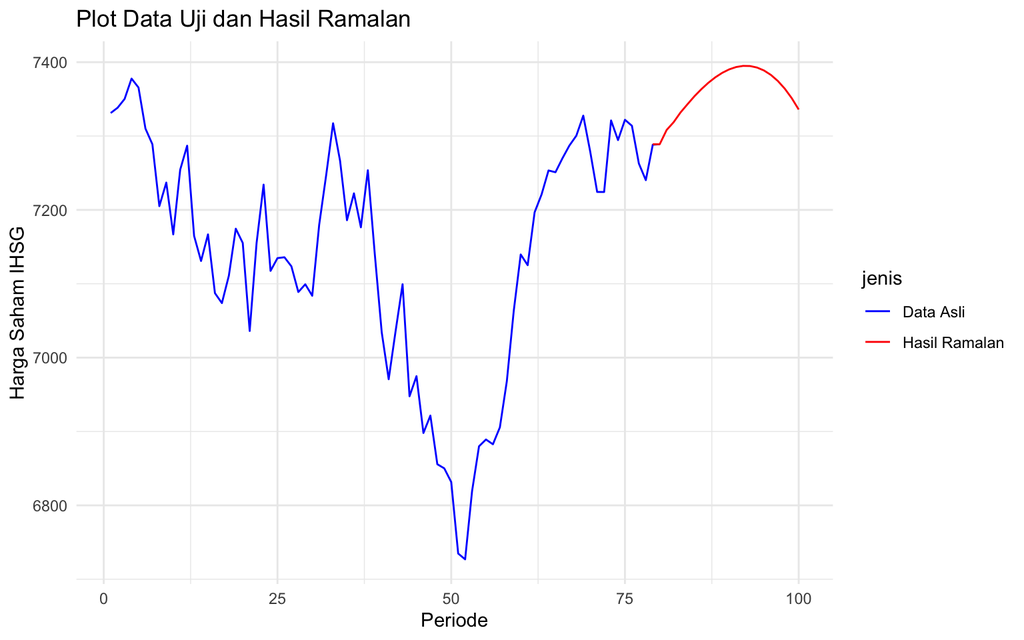

```r
pt_1 <- train.ts[80] #nilai akhir data latih
hasil.forc.Diff <- data.ramalan.da
hasil <- diffinv(hasil.forc.Diff, differences = 2) + pt_1
#has.1 sama hasilnta dengan: cumsum(c(pt_1,hasil.forc.Diff))

library(ggplot2)
data <- data.frame(waktu = c(time(train.ts),time(hasil)),
                   jumlah = c(as.numeric(train.ts),hasil),
                   jenis = c(rep("Data Asli",length(train.ts)),rep("Hasil Ramalan",length(hasil))))
ggplot(data, aes(x=waktu, y=jumlah, color=jenis)) + geom_line() +
  scale_color_manual(values = c("blue", "red")) +
  labs(title = "Plot Data Uji dan Hasil Ramalan", x = "Periode", y = "Harga Saham IHSG") +
  theme_minimal()
```

# Akurasi

```r
perbandingan.da<-matrix(data=c(head(test.ts, n=20), hasil[-1]),
                     nrow = 20, ncol = 2)
colnames(perbandingan.da)<-c("Aktual","Hasil Forecast")
perbandingan.da
```

```
##         Aktual Hasil Forecast
##  [1,] 7241.864       7288.897
##  [2,] 7255.762       7308.228
##  [3,] 7325.985       7318.672
##  [4,] 7308.123       7331.986
##  [5,] 7059.653       7343.054
##  [6,] 7129.215       7353.882
##  [7,] 7212.131       7363.469
##  [8,] 7195.121       7372.084
##  [9,] 7256.996       7379.460
## [10,] 7297.625       7385.556
## [11,] 7356.638       7390.236
## [12,] 7436.039       7393.403
## [13,] 7409.501       7394.946
## [14,] 7432.090       7394.757
## [15,] 7466.831       7392.727
## [16,] 7533.985       7388.750
## [17,] 7554.593       7382.717
## [18,] 7488.676       7374.520
## [19,] 7544.298       7364.051
## [20,] 7616.718       7351.202
```

```r
accuracy(ts(hasil[-1]), head(test.ts, n=20))
```

```
##                 ME     RMSE      MAE        MPE     MAPE      ACF1 Theil's U
## Test set -7.537757 139.6466 112.8345 -0.1402549 1.536928 0.7507482  1.834028
```